# Statistical Rethinking: Chapter 7

Simon Thornewill von Essen

2024-04-03

This chapter was about introducing ways to measure model error such as `LOOCV` `PSIS` and `WAIC`. There is a lot of code in this chapter but I’ll only be using what I think will be useful for later.

A lot of the start of this code was going to be laden with theory, that’s been removed to my Obsidian vault.

# Entropy

For a first, let’s discuss Entropy. We can create a function that evaluates a vector of values that are passed to it like so;

```r
H = function(p){
  H_tot = sum(p * log(p))
  return(-H_tot)
}

H(c(0.3, 0.7))
```

```
## [1] 0.6108643
```

# Kullback-Leibler Divergence

Next, let’s try and calculate the Kullback-Leibler divergence for these two vectors `q` and `p`

```r
q = c(0.25, 0.75)
p = c(0.3, 0.7)

D_KL = function(q, p){
  return(sum(p * log(p/q)))
}

D_KL(p, q)
```

```
## [1] 0.006164264
```

Note that $D_{\textrm{KL}}$ does not return the same values if you reverse the vectors. If you consider if you use the amount of water on Mars vs Earth to predict the amount on the other then you’d be more surprised seeing the earth after seeing Mars rather than seeing Mars after seeing the Earth.

This is because Mars has a lot less variability in terms of how much water/earth it’s covered by.

I’ll need to import some data for us to give this a shot, so give me a moment…

```r
sppnames = c("afarensis", "africanus", "habilis", "boisei", "rudolfensis",
             "ergaster", "sapiens")
brainvolcc = c(438, 452, 612, 521, 752, 871, 1350)
masskg = c(37, 35.5, 34.5, 41.5, 55.5, 61, 53.5)

d = data.frame(species=sppnames, brain=brainvolcc, mass=masskg)

d$mass_std = (d$mass - mean(d$mass))/sd(d$mass)
d$brain_std = (d$brain - mean(d$brain))/sd(d$brain)

m7.1 = quap(
  alist(
    brain_std ~ dnorm(mu, exp(log_sigma)),
    mu <- a + b*mass_std,
    a ~ dnorm(0.5, 1),
    b ~ dnorm(0, 10),
    log_sigma ~ dnorm(0, 1)
  ),
  data=d
)

set.seed(1)
logprob = sim(m7.1, ll=TRUE, n=1e4)
n = ncol(logprob)
ns = nrow(logprob)
```

This means for calculating the LPPD, that actually already brings us some of the way there…

We’ll be using this equation:
$$\textrm{lppd}(y, \Theta) = \sum_i
log(\frac{1}{S}\sum_s p(y_i|\Theta_s))$$
Let me try and apply this using my shitty crude ass code;

```r
lppd_tot = rep(0, 7)
for(j in 1:n){
  lppd_tot[j] = (log_sum_exp(logprob[, j])   - log(ns))
}

lppd_tot
```

```
## [1] -0.7431961 -0.6853224 -0.7823862 -0.7377067 -0.9299866 -0.9501771 -2.4280020
```

Let’s compare that to the code in the book…

```r
f = function(i) {return(log_sum_exp(logprob[, i]) - log(ns))}
lppd_tot = sapply(1:n, f)

lppd_tot
```

```
## [1] -0.7431961 -0.6853224 -0.7823862 -0.7377067 -0.9299866 -0.9501771 -2.4280020
```

Note that the `log_sum_exp` function does the equivalent of $\textrm{log}\sum\textrm{exp(x)}$. i.e. It takes the log probabilities and exponentiates them back into probabilities. Then we get the sum of the probabilities before turning it back into a log probability again.

Note that taking the log of `ns` and subtracting it means that we are dividing it.

In any case, the variable `lppd` (above) is a vector and it needs to be summed in order to get the lppd for all observations.

This is an interesting way to see what you can do with `sapply()`, where I’ve always thought of the number being the dimension that you pass but here it’s applied column-wise.

Anyway, this looks good… And now using the function from `rethinking`?

```r
set.seed(1)
lppd(m7.1, n=1e4)
```

```
## [1] -0.7431961 -0.6853224 -0.7823862 -0.7377067 -0.9299866 -0.9501771 -2.4280020
```

# Widely Applicable Information Criterion

Alright, now we’re getting into the important measures. In order to calculate WAIC, we need S (`ns`) samples from the posterior distribution…

```r
ns=1e3
set.seed(1)
post = extract.samples(m7.1, n=ns)
```

Now that we have the samples, we need to calculate the log-likelihood of each data point `i` in terms of these samples.

```r
logprob = sapply(1:ns,
                 function(s){
                   mu = post$a[s] + post$b[s]*d$mass_std
                   return(dnorm(d$brain_std, mu, exp(post$log_sigma[s]), log=TRUE))
                 }
                )

dim(logprob)
```

```
## [1]    7 1000
```

So, now for each 7 observations we have the log likelihood of that datapoint occurring for each sample from the posterior distribution ($\Theta_s$) (S)

As before, we need to calculate the `LPPD`…

```r
n_cases = nrow(d)
lppd_tot = sapply(1:n_cases,
              function(i) log_sum_exp(logprob[i, ]) - log(ns)
              )

sum(lppd_tot)
```

```
## [1] -7.252982
```

We then need to calculate the penalty term for the WAIC (`pWAIC`)

```r
pWAIC = sapply(1:n_cases,
               function(i) var(logprob[i,]))

WAIC_tot = -2*(sum(lppd_tot) - sum(pWAIC))

WAIC_tot
```

```
## [1] 26.53115
```

If we check this against the function, hopefully it’s the same…

```r
set.seed(1)
WAIC(m7.1, n=ns)
```

```
##       WAIC      lppd  penalty  std_err
## 1 26.53115 -7.252982 6.012594 10.30282
```

One further thing that I want to check is how to calculate that `std_err`…

```r
sqrt((n_cases-1) * var(-2*(lppd_tot - pWAIC)))
```

[output not shown]

It took me a while to realise that McElreath was using Bessel’s correction.

# Comparing Multiple Models

So, we don’t just want to look at one model but maybe we want to compare a couple of them. Towards that end I’ll need to fit a couple more…

```r
m7.2 = quap(
  alist(
    brain_std ~ dnorm(mu, exp(log_sigma)),
    mu <- a + b[1]*mass_std + b[2]*mass_std^2,
    a ~ dnorm(0.5, 1),
    b ~ dnorm(0, 10),
    log_sigma ~ dnorm(0, 1)
  ),
  data=d,
  start=list(b=rep(0, 2))
)

m7.3 = quap(
  alist(
    brain_std ~ dnorm(mu, exp(log_sigma)),
    mu <- a + b[1]*mass_std + b[2]*mass_std^2 + b[3]*mass_std^3,
    a ~ dnorm(0.5, 1),
    b ~ dnorm(0, 10),
    log_sigma ~ dnorm(0, 1)
  ),
  data=d,
  start=list(b=rep(0, 3))
)
```

Instead of saying the a sapiens brain size is linearly proportional to its mass, I also created models which have 2nd and 3rd degree polynomial terms.

```r
set.seed(1)
compare(m7.1, m7.2, m7.3, func=WAIC)
```

```
##          WAIC        SE   dWAIC       dSE    pWAIC     weight
## m7.1 26.53115 10.302816 0.00000        NA 6.012594 0.65757532
## m7.2 28.17864  7.888027 1.64749  3.590896 6.959555 0.28853444
## m7.3 31.53437 10.305662 5.00322 10.532722 9.823465 0.05389024
```

Note that in comparing these numbers, we don’t need to fit k-folds for n-out, we can use each of the 3 estimated posteriors to get estimates of these values.

We can also plot this comparison

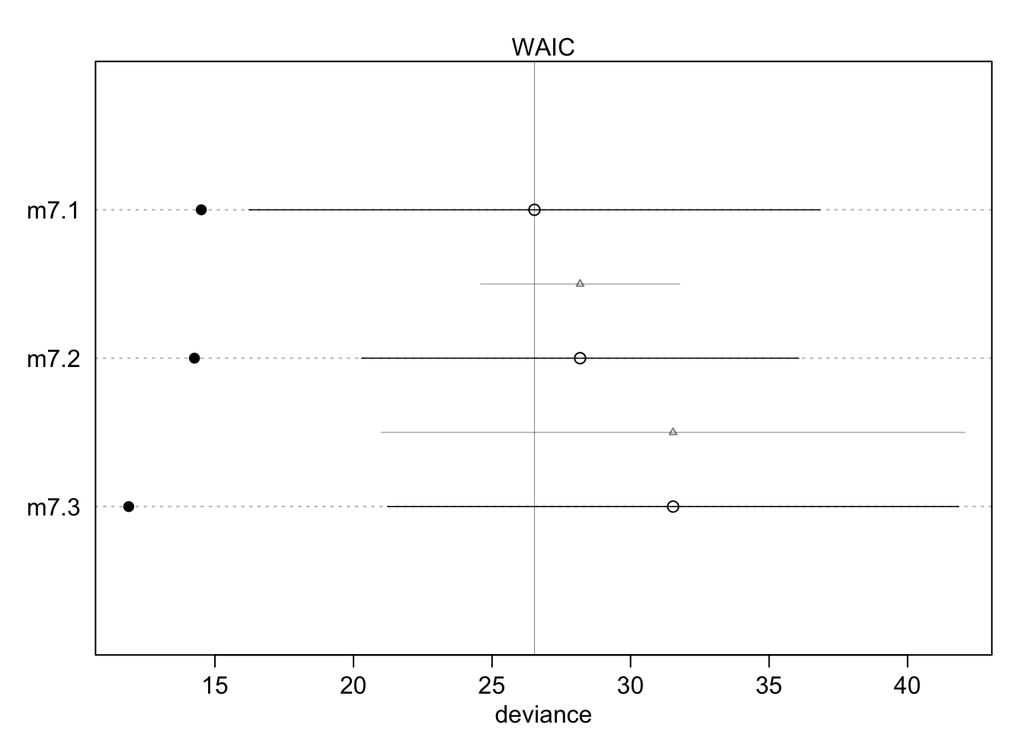

```r
set.seed(1)
plot(compare(m7.1, m7.2, m7.3, func=WAIC))
```

We can also look at the PSIS

```
## Some Pareto k values are very high (>1). Set pointwise=TRUE to inspect individual points.
## Some Pareto k values are very high (>1). Set pointwise=TRUE to inspect individual points.
## Some Pareto k values are very high (>1). Set pointwise=TRUE to inspect individual points.
```

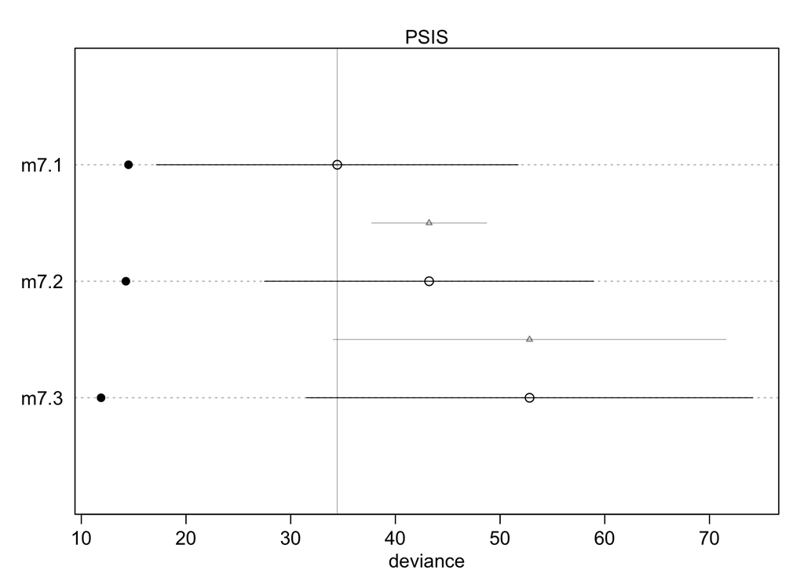

```r
set.seed(1)
plot(compare(m7.1, m7.2, m7.3, func=PSIS))
```

We can see that each model predicts worse than the 1st model which only has the linear term. Maybe as a practice exercise, I can try and use `ggplot2` to take a look and plot everything…

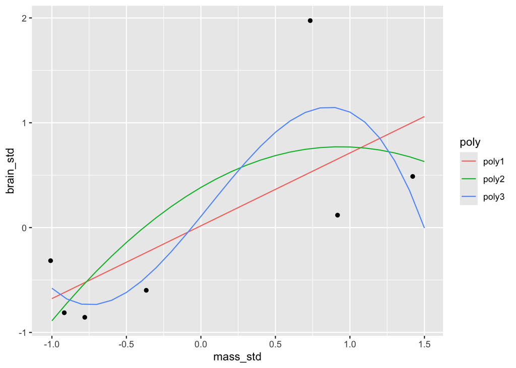

```r
d.pred = data.frame(mass_std=seq(-1, 1.5, 0.1))
d.pred$poly1 = apply(link(m7.1, data=d.pred), 2, mean)
d.pred$poly2 = apply(link(m7.2, data=d.pred), 2, mean)
d.pred$poly3 = apply(link(m7.3, data=d.pred), 2, mean)

d.pred = d.pred %>%
  melt(id="mass_std", variable.name="poly", value.name="brain_std")

ggplot(NULL) +
  geom_point(data=d, aes(x=mass_std, y=brain_std))+
  geom_line(data=d.pred, aes(x=mass_std, y=brain_std, color=poly))
```

To be fair, the data is so sparse that it’s difficult to really see which fit really should be the best. If we look at how each model prediction performs then we also find that the `WAIC` and `PSIS` metrics are also pretty unclear about this. We may apply Occam’s razor and just take the lowest `poly` (linear).

We can compare the difference in standard error by using the following code;

```r
set.seed(1)
compare(m7.1, m7.2, m7.3, func=WAIC)@dSE
```

```
##           m7.1     m7.2      m7.3
## m7.1        NA 3.590896 10.532722
## m7.2  3.590896       NA  9.411163
## m7.3 10.532722 9.411163        NA
```

We can also look at the weight of each point…

```r
set.seed(1)
d$penalty1 = PSIS(m7.1, n=1e3, pointwise=TRUE)$penalty
```

```
## Some Pareto k values are very high (>1). Set pointwise=TRUE to inspect individual points.
```

```r
d %>%
  select(c("species", "penalty1", "brain_std", "mass_std")) %>%
  arrange(penalty1)
```

```
##       species  penalty1  brain_std   mass_std
## 1      boisei 0.1216122 -0.5980316 -0.3668079
## 2   africanus 0.1414623 -0.8121526 -0.9170196
## 3   afarensis 0.1796344 -0.8555974 -0.7794667
## 4     habilis 0.2997337 -0.3156401 -1.0087216
## 5 rudolfensis 0.4894600  0.1188083  0.9170196
## 6    ergaster 1.3879610  0.4880895  1.4213804
## 7     sapiens 7.3499528  1.9745238  0.7336157
```

Haha, we can see that sapiens has a massive brain relative to its body-mass.